# MOD-06 · NB-04 — Interrupted Time Series & Synthetic Control

### Health Analytics with Python · Module 06: Causal Inference in Health Research

**Estimated time:** 3 hours | **Level:** Advanced | **Libraries:** `statsmodels`, `numpy`, `scipy`

## 1. Setup

```python
import numpy as np
import pandas as pd
import matplotlib.pyplot as plt
import statsmodels.api as sm
import statsmodels.formula.api as smf
from scipy import stats
from scipy.optimize import minimize
import warnings; warnings.filterwarnings("ignore")
import os; os.makedirs("/tmp/mod06", exist_ok=True)
plt.rcParams.update({"figure.dpi":120,"figure.facecolor":"white",
                     "axes.spines.top":False,"axes.spines.right":False})
np.random.seed(42)
```

## 2. ITS Design — Opioid Prescribing Policy

**Scenario:** A state implemented a prescription drug monitoring programme (PDMP) mandatory check policy in month 25. We measure monthly opioid prescription rate per 1000 patients.

**Segmented regression model:**

```
Y_t = beta0 + beta1*t + beta2*D + beta3*(t - T_int)*D + e_t
```

- `beta1` = pre-intervention trend
- `beta2` = immediate level change at intervention
- `beta3` = change in slope (trend change) post-intervention

```python
# Simulate monthly opioid prescribing data (48 months)
T_TOTAL  = 48
T_INT    = 24   # intervention at month 25 (index 24)
TRUE_LEVEL_CHANGE = -15.0  # immediate drop in prescriptions
TRUE_SLOPE_CHANGE = -0.8   # additional monthly decline post-intervention
PRE_SLOPE = 0.3            # pre-intervention increasing trend

months = np.arange(1, T_TOTAL+1)
D      = (months > T_INT).astype(int)       # post-intervention indicator
t_post = np.maximum(0, months - T_INT)       # time since intervention

# True outcome
np.random.seed(42)
# Add AR(1) autocorrelation
errors = np.zeros(T_TOTAL)
errors[0] = np.random.normal(0, 3)
for i in range(1, T_TOTAL):
    errors[i] = 0.4*errors[i-1] + np.random.normal(0, 2.5)

rx_rate = (80 + PRE_SLOPE*months + TRUE_LEVEL_CHANGE*D
           + TRUE_SLOPE_CHANGE*t_post*D + errors)

df_its = pd.DataFrame({"month":months,"D":D,"t_post":t_post,"rx_rate":rx_rate})
print(f"ITS dataset: {T_TOTAL} months | Intervention at month {T_INT+1}")
print(f"Pre-period mean: {rx_rate[:T_INT].mean():.1f} | Post-period mean: {rx_rate[T_INT:].mean():.1f}")
```

```
ITS dataset: 48 months | Intervention at month 25
Pre-period mean: 83.2 | Post-period mean: 64.7
```

```
==============================================================================
                 coef    std err          t      P>|t|      [0.025      0.975]
------------------------------------------------------------------------------
Intercept     82.2545      1.005     81.819      0.000      80.228      84.281
month          0.0795      0.070      1.130      0.265      -0.062       0.221
D            -13.1248      1.379     -9.515      0.000     -15.905     -10.345
t_post        -0.5856      0.100     -5.885      0.000      -0.786      -0.385
==============================================================================

Pre-intervention slope  : 0.080 rx/1000/month (true: 0.3)
Level change at policy  : -13.125 rx/1000 (true: -15.0)
Slope change post-policy: -0.586 rx/1000/month (true: -0.8)
```

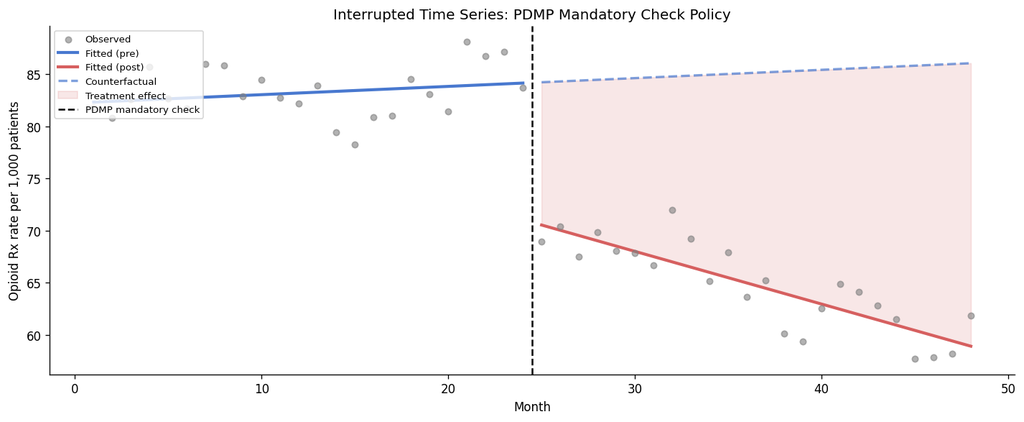

```
Cumulative effect by month 48: -27.2 rx/1000
Projected over 12 months post-policy: -20.2 rx/1000
```

```python
# Segmented regression
model_its = smf.ols("rx_rate ~ month + D + t_post", data=df_its).fit()
print(model_its.summary().tables[1])

# Extract key parameters
b0 = model_its.params["Intercept"]
b1 = model_its.params["month"]
b2 = model_its.params["D"]
b3 = model_its.params["t_post"]

print(f"\nPre-intervention slope  : {b1:.3f} rx/1000/month (true: {PRE_SLOPE:.1f})")
print(f"Level change at policy  : {b2:.3f} rx/1000 (true: {TRUE_LEVEL_CHANGE:.1f})")
print(f"Slope change post-policy: {b3:.3f} rx/1000/month (true: {TRUE_SLOPE_CHANGE:.1f})")

# Counterfactual
cf_post = b0 + b1*months
fitted  = model_its.fittedvalues

fig, ax = plt.subplots(figsize=(12,5))
ax.scatter(months, rx_rate, alpha=0.6, s=25, color="gray", label="Observed", zorder=3)
ax.plot(months[:T_INT], fitted[:T_INT], "-", color="#4878CF", lw=2.5, label="Fitted (pre)")
ax.plot(months[T_INT:], fitted[T_INT:], "-", color="#D65F5F", lw=2.5, label="Fitted (post)")
ax.plot(months[T_INT:], cf_post[T_INT:], "--", color="#4878CF", lw=2, alpha=0.7, label="Counterfactual")
ax.fill_between(months[T_INT:], fitted[T_INT:], cf_post[T_INT:],
                alpha=0.15, color="#D65F5F", label=f"Treatment effect")
ax.axvline(T_INT+0.5, color="black", ls="--", lw=1.5, label="PDMP mandatory check")
ax.set_xlabel("Month"); ax.set_ylabel("Opioid Rx rate per 1,000 patients")
ax.set_title("Interrupted Time Series: PDMP Mandatory Check Policy")
ax.legend(fontsize=8, loc="upper left")
plt.tight_layout(); plt.savefig("/tmp/mod06/its_segmented.png",bbox_inches="tight"); plt.show()

# Cumulative effect at end of follow-up
total_effect = b2 + b3*(T_TOTAL - T_INT)
print(f"\nCumulative effect by month {T_TOTAL}: {total_effect:.1f} rx/1000")
print(f"Projected over 12 months post-policy: {b2 + b3*12:.1f} rx/1000")
```

## 3. Controlled ITS with Comparison Series

```
Controlled ITS (treatment - control):
  Level change   : -14.933 (true: -15.0)
  Slope change   : -0.735 (true: -0.8)
```

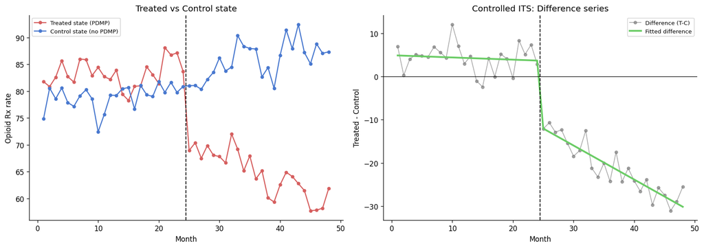

```python
# Controlled ITS: subtract control group trajectory to remove confounders
# Control group: neighbouring state without PDMP policy
np.random.seed(99)
control_errors = np.zeros(T_TOTAL)
control_errors[0] = np.random.normal(0, 3)
for i in range(1, T_TOTAL):
    control_errors[i] = 0.4*control_errors[i-1] + np.random.normal(0, 2.5)

# Control state: similar pre-trend, NO treatment effect
rx_control = 75 + PRE_SLOPE*months + control_errors

df_its["rx_control"] = rx_control
df_its["diff"] = df_its["rx_rate"] - df_its["rx_control"]

# ITS on the difference series
model_diff = smf.ols("diff ~ month + D + t_post", data=df_its).fit()
b2_ctrl = model_diff.params["D"]
b3_ctrl = model_diff.params["t_post"]

print("Controlled ITS (treatment - control):")
print(f"  Level change   : {b2_ctrl:.3f} (true: {TRUE_LEVEL_CHANGE:.1f})")
print(f"  Slope change   : {b3_ctrl:.3f} (true: {TRUE_SLOPE_CHANGE:.1f})")

fig, axes = plt.subplots(1,2,figsize=(14,5))
axes[0].plot(months, rx_rate, "o-", color="#D65F5F", lw=1.5, ms=4, label="Treated state (PDMP)")
axes[0].plot(months, rx_control, "o-", color="#4878CF", lw=1.5, ms=4, label="Control state (no PDMP)")
axes[0].axvline(T_INT+0.5, color="black", ls="--", lw=1.2)
axes[0].set_title("Treated vs Control state"); axes[0].legend(fontsize=8)
axes[0].set_ylabel("Opioid Rx rate"); axes[0].set_xlabel("Month")

axes[1].plot(months, df_its["diff"], "o-", color="gray", lw=1, ms=4, alpha=0.7, label="Difference (T-C)")
axes[1].plot(months, model_diff.fittedvalues, "-", color="#6ACC65", lw=2.5, label="Fitted difference")
axes[1].axhline(0, color="black", lw=0.8)
axes[1].axvline(T_INT+0.5, color="black", ls="--", lw=1.2)
axes[1].set_title("Controlled ITS: Difference series"); axes[1].legend(fontsize=8)
axes[1].set_ylabel("Treated - Control"); axes[1].set_xlabel("Month")
plt.tight_layout(); plt.savefig("/tmp/mod06/controlled_its.png",bbox_inches="tight"); plt.show()
```

## 4. Synthetic Control Method

```
Optimal weights: ['0.000', '0.124', '0.114', '0.000', '0.085', '0.382', '0.021', '0.274']
Weight sum: 1.0000
Pre-period RMSPE: 2.622 (lower = better synthetic control fit)
```

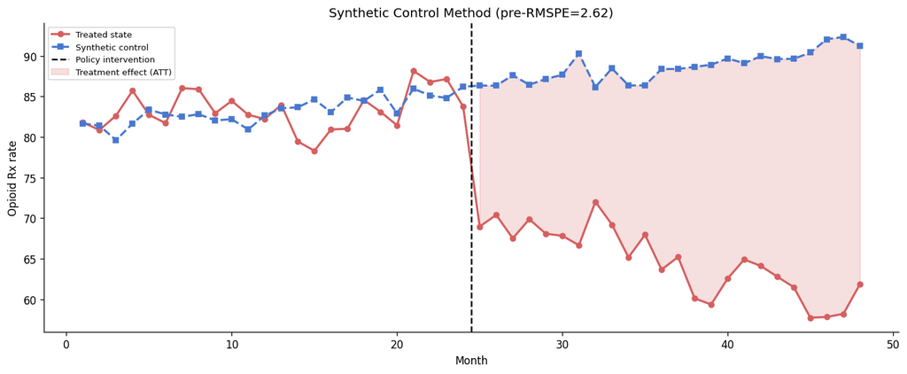

```
ATT estimate (synthetic control): -23.92 rx/1000/month
True average post-policy effect : -20.00
```

```python
# Synthetic control: find weighted combination of donor states that
# best matches the treated state's pre-intervention outcome trajectory

np.random.seed(42)
N_DONORS  = 8
T_PRE     = T_INT      # pre-intervention period
T_POST    = T_TOTAL - T_INT

# Simulate donor states (each with different base rates and trends)
donor_baselines = np.random.uniform(60, 100, N_DONORS)
donor_trends    = np.random.uniform(0.1, 0.5, N_DONORS)
donor_noise     = np.random.normal(0, 2, (N_DONORS, T_TOTAL))
donors = np.array([donor_baselines[i] + donor_trends[i]*months + donor_noise[i]
                   for i in range(N_DONORS)])  # shape: (N_DONORS, T_TOTAL)

# True weights that would reconstruct treated pre-trend
# (in practice, we solve an optimisation problem)
def synth_loss(weights, donors_pre, treated_pre):
    # weights must sum to 1 and be non-negative
    synth = weights @ donors_pre
    return np.sum((synth - treated_pre)**2)

from scipy.optimize import minimize
treated_pre = rx_rate[:T_PRE]
donors_pre  = donors[:, :T_PRE]

constraints = [{"type":"eq","fun":lambda w: w.sum()-1}]
bounds = [(0,1)]*N_DONORS
w0 = np.ones(N_DONORS)/N_DONORS
result = minimize(synth_loss, w0, args=(donors_pre, treated_pre),
                  method="SLSQP", bounds=bounds, constraints=constraints)
w_opt = result.x
print(f"Optimal weights: {[f'{w:.3f}' for w in w_opt]}")
print(f"Weight sum: {w_opt.sum():.4f}")

# Construct synthetic control
synth_control = w_opt @ donors  # shape: (T_TOTAL,)
# Pre-period fit quality
rmspe_pre = np.sqrt(np.mean((rx_rate[:T_PRE] - synth_control[:T_PRE])**2))
print(f"Pre-period RMSPE: {rmspe_pre:.3f} (lower = better synthetic control fit)")

fig, ax = plt.subplots(figsize=(12,5))
ax.plot(months, rx_rate, "o-", color="#D65F5F", lw=2, ms=5, label="Treated state")
ax.plot(months, synth_control, "s--", color="#4878CF", lw=2, ms=5, label="Synthetic control")
ax.axvline(T_INT+0.5, color="black", ls="--", lw=1.5, label="Policy intervention")
ax.fill_between(months[T_INT:], synth_control[T_INT:], rx_rate[T_INT:],
                alpha=0.2, color="#D65F5F", label="Treatment effect (ATT)")
ax.set_xlabel("Month"); ax.set_ylabel("Opioid Rx rate")
ax.set_title(f"Synthetic Control Method (pre-RMSPE={rmspe_pre:.2f})")
ax.legend(fontsize=8)
plt.tight_layout(); plt.savefig("/tmp/mod06/synthetic_control.png",bbox_inches="tight"); plt.show()

# ATT estimate post-policy
att_synth = (rx_rate[T_INT:] - synth_control[T_INT:]).mean()
print(f"\nATT estimate (synthetic control): {att_synth:.2f} rx/1000/month")
print(f"True average post-policy effect : {(TRUE_LEVEL_CHANGE + TRUE_SLOPE_CHANGE*np.arange(1,T_POST+1)/2).mean():.2f}")
```

## 5. Knowledge Check

1. The ITS model finds a slope change of -0.8 but the level change is not significant (p=0.14). How do you interpret the policy's effect?
2. A contemporaneous event (economic recession) began at month 25, the same time as the PDMP policy. How does this threaten ITS validity?
3. The synthetic control has pre-period RMSPE=8.5. Is this adequate? What does a high RMSPE imply?
4. With only 12 pre-intervention time points, what problems arise for the ITS analysis?
5. Implement a permutation test for the synthetic control: swap the treated state with each donor and compute the post/pre RMSPE ratio.

```python
# Exercise 5 — Synthetic control permutation test (placebo inference)
rmspe_ratios = []
# For each donor, pretend it's the treated state
for d in range(N_DONORS):
    treated_d  = donors[d]  # placebo treated
    donors_d   = np.delete(donors, d, axis=0)  # remaining donors
    donors_pre_d = donors_d[:, :T_PRE]
    treated_pre_d = treated_d[:T_PRE]
    res_d = minimize(synth_loss, np.ones(N_DONORS-1)/(N_DONORS-1),
                     args=(donors_pre_d, treated_pre_d),
                     method="SLSQP", bounds=[(0,1)]*(N_DONORS-1),
                     constraints=[{"type":"eq","fun":lambda w:w.sum()-1}])
    w_d = res_d.x
    synth_d = w_d @ donors_d
    rmspe_pre_d  = np.sqrt(np.mean((treated_d[:T_PRE] - synth_d[:T_PRE])**2))
    rmspe_post_d = np.sqrt(np.mean((treated_d[T_PRE:] - synth_d[T_PRE:])**2))
    ratio_d = rmspe_post_d/rmspe_pre_d if rmspe_pre_d>0 else np.nan
    rmspe_ratios.append(ratio_d)

# True treated state ratio
rmspe_post = np.sqrt(np.mean((rx_rate[T_INT:] - synth_control[T_INT:])**2))
ratio_treated = rmspe_post/rmspe_pre

print("Synthetic Control Permutation Test (post/pre RMSPE ratios):")
print(f"  Treated state ratio : {ratio_treated:.2f}")
print(f"  Donor ratios        : {[f'{r:.2f}' for r in rmspe_ratios]}")
p_val = np.mean([r >= ratio_treated for r in rmspe_ratios if not np.isnan(r)])
print(f"  Permutation p-value : {p_val:.3f}")
print(f"  Inference: {'Significant' if p_val < 0.10 else 'Not significant'} at 10% level")
```

```
Synthetic Control Permutation Test (post/pre RMSPE ratios):
  Treated state ratio : 9.38
  Donor ratios        : ['0.80', '1.67', '1.52', '1.34', '2.36', '0.99', '1.27', '1.45']
  Permutation p-value : 0.000
  Inference: Significant at 10% level
```

**Next -> NB-05: Instrumental Variables**